# Homework 6

- Show All Code
- Hide All Code
- View Source

Author

DATASCI/STATS 531, Liangqi Tang

Please submit your homework report to Canvas, including both the Rmarkdown (.Rmd) source file and an HTML file compiled from it. If necessary, you can submit other files needed for your Rmd file to compile, but please do not submit a copy of the data. Your Rmd file can read in the Consett measles data from the internet, via

```r
read.csv("https://kingaa.github.io/sbied/stochsim/Measles_Consett_1948.csv")
```

Your report should contain a reference section listing sources. The grader should be able to clearly identify where the sources were used, for example using reference numbers in the text. Anything and anyone consulted while you are working on the homework counts as a source and should be credited. The homework will be graded following the grading scheme in the syllabus.

This homework is conceptually quite simple, but involves overcoming various technical hurdles. The hurdles may be overcome quite quickly, or could turn into a longer battle. To make progress on statistical inference for POMP models, we have to solve these underlying computational issues. If technical difficulties arise, do not wait long before asking your colleagues, coming to office hours, or posting on Piazza.

# Installing the **pomp** package

- Computation time is an unavoidable consideration when working with simulation-based inference, for all but small datasets and simple models.
- The **pomp** package therefore allows you to specify the most computationally intensive steps—usually, simulation of the stochastic dynamic system, and evaluation of the measurement density—as snippets of C code.
- Consequently, to use **pomp**, your R program must have access to a C compiler. In addition, **pomp** takes advantage of some Fortran code and therefore requires a Fortran compiler.
- Installing the necessary compilers should be fairly routine, but does involve an extra step beyond the usual installation of an R package, unless you are running the Linux operating system for which they are usually installed by default. Given how fundamental C and Fortran are to scientific computing, it is unfortunate that Mac and Windows do not provide these compilers by default.
- Detailed instructions for installing **pomp** and other software that we will use with it are provided in the following places:
  - The [pomp website installation page](https://kingaa.github.io/pomp/install.html)
  - Additional instructions on our [course website](https://ionides.github.io/531w24/pomp_prep/index.html)

# Homework questions

## Question 6.1.

Exploring behavior of a POMP model: simulating an SIR process.

Write a solution to Exercise 2.3 from Chapter 12 (Simulation of stochastic dynamic models). Note the following:

- We are working toward formal inference for POMP models. Nevertheless, playing with your model by plotting simulations at various parameter values is a useful exercise for getting to understand how your model behaves. It is not enough to know just what parameter value maximizes the likelihood, we also want to understand enough about the model to be able to interpret this MLE. What types of behavior can the model exhibit? How could we describe the behaviors that are consistent with the data?
- Your solution will have to build a copy of the measles model so that you can experiment with it. The [Chapter 12 R script](https://kingaa.github.io/sbied/stochsim/main.R) may be useful. The script uses Hadley Wickham’s `tidyverse` and `ggplot` approach to R. This is a widely used approach, and well worth learning if you have not seen it before, but you may also stick with basic R. To read the script, you will need to know that `x |> myfunc(y)` is equivalent to `myfunc(x,y)`, so `|>` is simply a convenient way to chain together functions, where the output of one function is piped into the next. Check that you understand this syntax for the code

```r
readr::read_csv("https://kingaa.github.io/sbied/stochsim/Measles_Consett_1948.csv") |>
  dplyr::select(week,reports=cases) -> meas
```

- Here, we use the function `read_csv` from `readr`, which is part of `tidyverse`, in place of the basic R function `read.csv`.
- Worked solutions are linked from the notes, if you get stuck. Ideally, you may like to look at them after solving the homework independently. Your solution is welcome to discuss the relationship between your investigation of the model and the posted solutions.
- Another example of building a pomp model is the [Ricker model](https://kingaa.github.io/sbied/intro/ricker.html), originally developed to model fish populations and used in this example to model a bird population.
- Various other tutorials and resources are available on the [pomp package web site](https://kingaa.github.io/pomp/docs.html).

**Answer**:

In this question, the code is basically copied or modified from the [class slides](https://kingaa.github.io/sbied/stochsim/slides.pdf)

Firstly, we load the data and plot the original data:

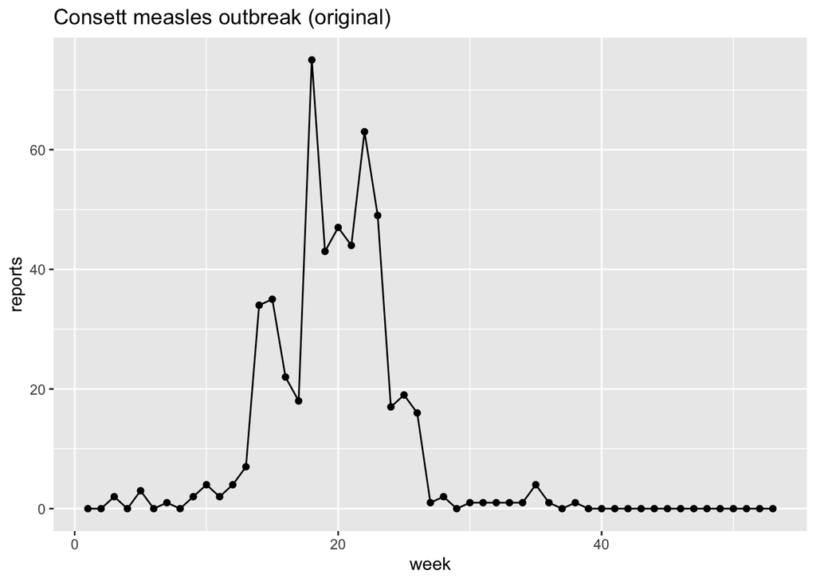

```r
# load the data
library(tidyverse)
library(ggplot2)
read_csv(paste0("https://kingaa.github.io/sbied/stochsim/",
  "Measles_Consett_1948.csv")) |>
  select(week,reports=cases) -> meas

# plot the original data
meas |> as.data.frame() |>
  ggplot(aes(x=week,y=reports))+
  geom_line()+
  geom_point()+
  ggtitle("Consett measles outbreak (original)")
```

Then we add components to pomp models:

```r
# implement the SIR model in pomp
library(pomp)

# step function
sir_step <- function (S, I, R, N, Beta, mu_IR, delta.t,
  H, ...) {
  dN_SI <- rbinom(n=1,size=S,prob=1-exp(-Beta*I/N*delta.t))
  dN_IR <- rbinom(n=1,size=I,prob=1-exp(-mu_IR*delta.t))
  S <- S - dN_SI
  I <- I + dN_SI - dN_IR
  R <- R + dN_IR
  H <- H + dN_IR
  c(S = S, I = I, R = R, H = H)
}

# initial function
sir_rinit <- function (N, eta, ...) {
  c(S = round(N*eta), I = 1, R = round(N*(1-eta)), H = 0)
}

# basic pomp model
meas |>
  pomp(times="week",t0=0,
    rprocess=euler(sir_step,delta.t=1/7),
    rinit=sir_rinit, accumvars="H"
  ) -> measSIR

# dmeasure component
sir_dmeas <- function (reports, H, rho, k, log, ...) {
  dnbinom(x=reports, size=k, mu=rho*H, log=log)
}

# rmeasure component
sir_rmeas <- function (H, rho, k, ...) {
  c(reports=rnbinom(n=1, size=k, mu=rho*H))
}

# add dmeasure and rmeasure to pomp
measSIR |>
  pomp(
    rmeasure=sir_rmeas,
    dmeasure=sir_dmeas
  ) -> measSIR
```

Next, I choose plausible parameter values, adjust them and plot the simulation:

Adjust process is as follows:

1. first I keep $\mathcal{R}_0 = 15$ and adjust $\beta$ and $\mu_{IR}$ simultaneously but I found out that only in the first few weeks the simulation values would be non-zero. This indicated that we might wrongly estimate the $\mathcal{R}_0 = 15$. Thus I separately addjust the value of $\beta$ and $\mu_{IR}$ and get the results below.
2. Then when I adjust the value of $\rho$, I found that the larger the value of $\rho$ is, the larger the peak value of the simulation and vice versa. $\rho =0.5$ is already the best choice.
3. The $k$ value does not have much influence on the simulation. Generally I choose $k = 20$ since I found the simulation results show the better relationship between the two peaks.
4. $\eta$ basically affect the position of the peak values and $eta = 0.03$ is already a very good choice.

The final simulation result of my chosen parameters are as follows:

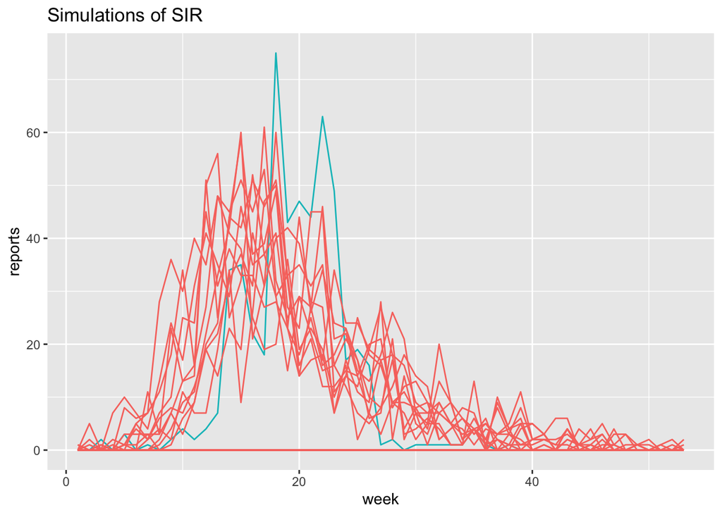

```r
# generate simulations based on the parameter values we choose:
measSIR |>
  simulate(
    params=c(Beta=25,mu_IR=0.15,rho=0.5,k=20,
      eta=0.03,N=38000),
    nsim=20,format="data.frame",include.data=TRUE
  ) -> sims

# plot the simulations
sims |>
  ggplot(aes(x=week,y=reports,group=.id,color=.id=="data"))+
  geom_line()+
  guides(color="none")+
  ggtitle("Simulations of SIR")
```

After I finished my adjustments to the parameters, I compared it with the [worked solutions](https://kingaa.github.io/sbied/stochsim/exercises.html) posted on class website. Basically the worked solutions also change the $\beta$ and $\mu_{IR}$ separately, thus override our preconfigured $\mathcal{R}_0$. Besides I additionally change the value of $k$.

## Question 6.2.

Modifying a POMP model: Adding a latent period to the SIR model**

Write a solution to Exercise 2.4 from Chapter 12 (Simulation of stochastic dynamic models).

You should use Csnippets for this. It should not require techniques beyond those developed in Chapter 12. However, if you are interested in learning more about writing compiled C code for R, you can look at the [R extensions manual](https://cran.r-project.org/doc/manuals/r-release/R-exts.html). The section on [distribution functions](https://cran.r-project.org/doc/manuals/r-release/R-exts.html#Distribution-functions) is particularly relevant.

**Answer**:

In this question, the code is basically copied or modified from the [class slides](https://kingaa.github.io/sbied/stochsim/slides.pdf) and [worked solutions](https://kingaa.github.io/sbied/stochsim/exercises.html).

Firstly, we re-write the pomp model using `Csnippet`: basically we treat E in the same way as I.

```r
# step function: E is similar to the component I, add E in the chain
seir_step <- Csnippet("
  double dN_SE = rbinom(S,1-exp(-Beta*I/N*dt));
  double dN_EI = rbinom(E,1-exp(-mu_EI*dt));
  double dN_IR = rbinom(I,1-exp(-mu_IR*dt));
  S -= dN_SE;
  E += dN_SE - dN_EI;
  I += dN_EI - dN_IR;
  R += dN_IR;
  H += dN_IR;
")

# initial function: suppose we do not no the latent value of E at first.
seir_rinit <- Csnippet("
  S = nearbyint(eta*N);
  E = 0;
  I = 1;
  R = nearbyint((1-eta)*N);
  H = 0;
")

# dmeasure component
seir_dmeas <- Csnippet("
  lik = dnbinom_mu(reports,k,rho*H,give_log);
")

# rmeasure component
seir_rmeas <- Csnippet("
  reports = rnbinom_mu(k,rho*H);
")

# add components to pomp model: clarify E and mu_EI
meas |>
  pomp(times="week",t0=0,
    rprocess=euler(seir_step,delta.t=1/7),
    rinit=seir_rinit,
    rmeasure=seir_rmeas,
    dmeasure=seir_dmeas,
    accumvars="H",
    statenames=c("S","E","I","R","H"),
    paramnames=c("Beta","mu_EI","mu_IR","N","eta","rho","k")
  ) -> measSEIR
```

Then change the parameters and simulate:

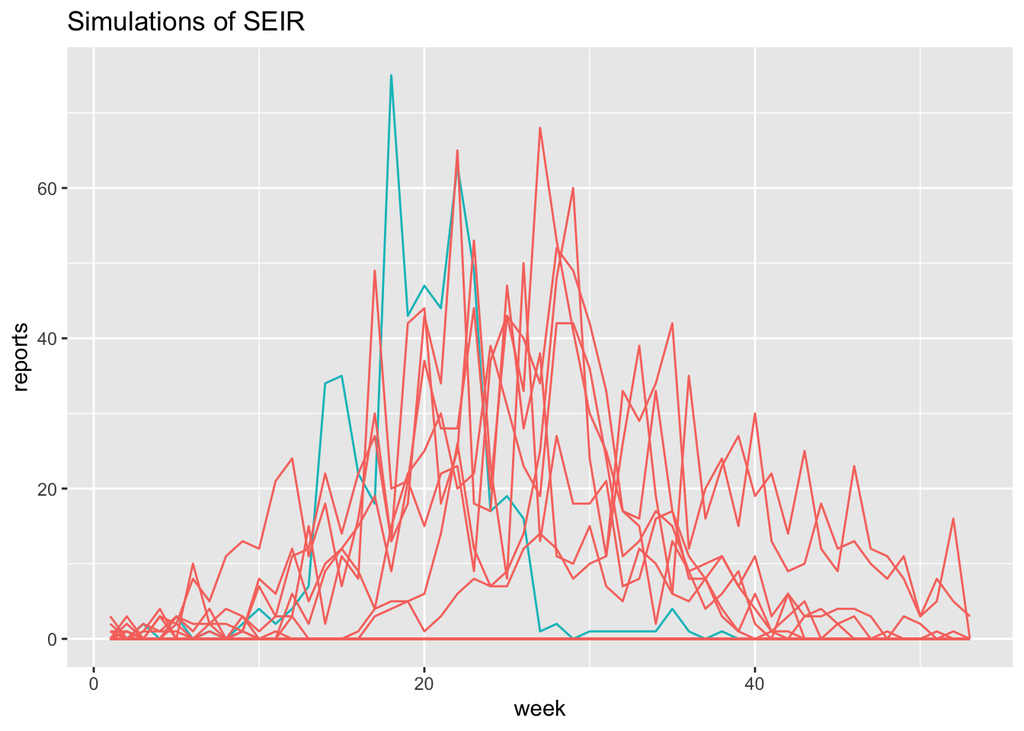

```r
# generate simulations based on the parameter values we choose:
measSEIR |>
  simulate(
    params=c(Beta=30,mu_EI=0.8,mu_IR=1,rho=0.5,k=10,
      eta=0.05,N=38000),
    nsim=20,format="data.frame",include.data=TRUE
  ) -> sims

# plot the simulations
sims |>
  ggplot(aes(x=week,y=reports,group=.id,color=.id=="data"))+
  geom_line()+
  guides(color="none")+
  ggtitle("Simulations of SEIR")
```

From the simulation results, it seems that by including a latent period we can not get much improvement.

# Acknowledgements

The questions derive from material in a short course on [Simulation-based Inference for Epidemiological Dynamics](http://kingaa.github.io/sbied/index.html)

# Reference

- 1. [class slides](https://kingaa.github.io/sbied/stochsim/slides.pdf)
- 2. [worked solutions](https://kingaa.github.io/sbied/stochsim/exercises.html)